# Reproducible Research, Peer Assignment 2 - Storm Data Analysis

#### 1. Synopsis

Many natural events, such as storms, flood, tornado, will have unprediciable impact on both public health and economics. They may result in fatalities, injureis and also property damage.

The U.S. National Oceanic and Atmospheric Administration’s (NOAA) storm database will be used in this project. This database tracks characteristics of major storms and weather events in the United States, including but not limited to when and where they occur, as well as estimates of any fatalities, injuries, and property damage.

The two major questions will be answered in this documnet are:  
1. Across the United States, which types of events are most harmful with respect to population health, more specifically fatalities and injuries?

2. Across the United States, which types of events have the greatest economic consequences?

#### 2. Data Processing

##### 2.2 Install and load packages

```r
## If the pakcage doesn't exist, using: install.packages('data.table')
## This package is used for processing the data file
library(data.table)
## If the pakcage doesn't exist, using: install.packages('ggplot2')
## This package is used for plotting result
library(ggplot2)
```

Download and uncompress the data, the load data in to R.

```r
data <- read.csv(paste(dataDir, "repdata-data-StormData.csv", sep = ""))
```

##### 2.3 Basic Data Info

Structure of the data

```r
str(data)
```

```
## 'data.frame':    902297 obs. of  37 variables:
##  $ STATE__   : num  1 1 1 1 1 1 1 1 1 1 ...
##  $ BGN_DATE  : Factor w/ 16335 levels "1/1/1966 0:00:00",..: 6523 6523 4242 11116 2224 2224 2260 383 3980 3980 ...
##  $ BGN_TIME  : Factor w/ 3608 levels "00:00:00 AM",..: 272 287 2705 1683 2584 3186 242 1683 3186 3186 ...
##  $ TIME_ZONE : Factor w/ 22 levels "ADT","AKS","AST",..: 7 7 7 7 7 7 7 7 7 7 ...
##  $ COUNTY    : num  97 3 57 89 43 77 9 123 125 57 ...
##  $ COUNTYNAME: Factor w/ 29601 levels "","5NM E OF MACKINAC BRIDGE TO PRESQUE ISLE LT MI",..: 13513 1873 4598 10592 4372 10094 1973 23873 24418 4598 ...
##  $ STATE     : Factor w/ 72 levels "AK","AL","AM",..: 2 2 2 2 2 2 2 2 2 2 ...
##  $ EVTYPE    : Factor w/ 985 levels "   HIGH SURF ADVISORY",..: 834 834 834 834 834 834 834 834 834 834 ...
##  $ BGN_RANGE : num  0 0 0 0 0 0 0 0 0 0 ...
##  $ BGN_AZI   : Factor w/ 35 levels "","  N"," NW",..: 1 1 1 1 1 1 1 1 1 1 ...
##  $ BGN_LOCATI: Factor w/ 54429 levels ""," Christiansburg",..: 1 1 1 1 1 1 1 1 1 1 ...
##  $ END_DATE  : Factor w/ 6663 levels "","1/1/1993 0:00:00",..: 1 1 1 1 1 1 1 1 1 1 ...
##  $ END_TIME  : Factor w/ 3647 levels ""," 0900CST",..: 1 1 1 1 1 1 1 1 1 1 ...
##  $ COUNTY_END: num  0 0 0 0 0 0 0 0 0 0 ...
```

[output cut: 23 more lines]

Summary of the data

```r
head(data)
```

```
##   STATE__           BGN_DATE BGN_TIME TIME_ZONE COUNTY COUNTYNAME STATE
## 1       1  4/18/1950 0:00:00     0130       CST     97     MOBILE    AL
## 2       1  4/18/1950 0:00:00     0145       CST      3    BALDWIN    AL
## 3       1  2/20/1951 0:00:00     1600       CST     57    FAYETTE    AL
## 4       1   6/8/1951 0:00:00     0900       CST     89    MADISON    AL
## 5       1 11/15/1951 0:00:00     1500       CST     43    CULLMAN    AL
## 6       1 11/15/1951 0:00:00     2000       CST     77 LAUDERDALE    AL
##    EVTYPE BGN_RANGE BGN_AZI BGN_LOCATI END_DATE END_TIME COUNTY_END
## 1 TORNADO         0                                               0
## 2 TORNADO         0                                               0
## 3 TORNADO         0                                               0
## 4 TORNADO         0                                               0
## 5 TORNADO         0                                               0
## 6 TORNADO         0                                               0
##   COUNTYENDN END_RANGE END_AZI END_LOCATI LENGTH WIDTH F MAG FATALITIES
```

[output cut: 20 more lines]

##### 2.4 Data Clearning and Pre-processing

Convert fatalities and injuries into numerical values

```r
data$FATALITIES <- as.numeric(data$FATALITIES)
data$INJURIES <- as.numeric(data$INJURIES)
```

Convert event type into factor

```r
data$EVTYPE <- as.factor(data$EVTYPE)
```

#### 3. Result

##### 3.1 The most harmful events result in fatalities

Read the data into data.table:

```r
fatalities <- as.data.table(subset(aggregate(FATALITIES ~ EVTYPE, data = data,
                                             FUN = "sum"), FATALITIES > 0))
```

Select the top 25 events and reorder the factor level:

```r
fatalities <- fatalities[order(-FATALITIES), ]
fatalities$EVTYPE <- reorder(fatalities$EVTYPE, fatalities$FATALITIES)
top25 <- fatalities[1:25, ]
```

Plot the top 25 events causing fatalities:

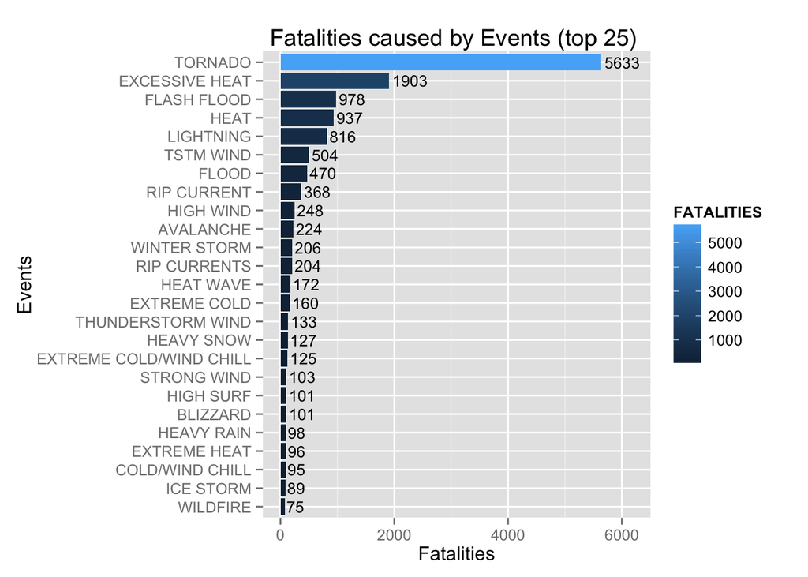

```r
ggplot(data = top25, aes(ymin=0, ymax=FATALITIES+FATALITIES * 0.1,
                         x=EVTYPE, y=FATALITIES, fill = FATALITIES) ) +
    geom_bar(stat = "identity") +
    xlab("Events") +
    ylab("Fatalities") +
    ggtitle("Fatalities caused by Events (top 25) ") +
    coord_flip() +
    geom_text(size=3.5, aes(label=FATALITIES),
              position = position_dodge(width=0.1), hjust = -0.1)
```

As shown in the plot above, tornado is the most harmful event which causes fatalities.

##### 3.2 The most harmful events result in injuries

Read the data into data.table:

```r
library(data.table)
injuries <- as.data.table(subset(aggregate(INJURIES ~ EVTYPE, data = data,
                                           FUN = "sum"), INJURIES > 0))
```

Select the top 25 events and reorder the factor level:

```r
injuries <- injuries[order(-INJURIES), ]
injuries$EVTYPE <- reorder(injuries$EVTYPE, injuries$INJURIES)
top25 <- injuries[1:25, ]
```

Plot the top 25 events causing injuries:

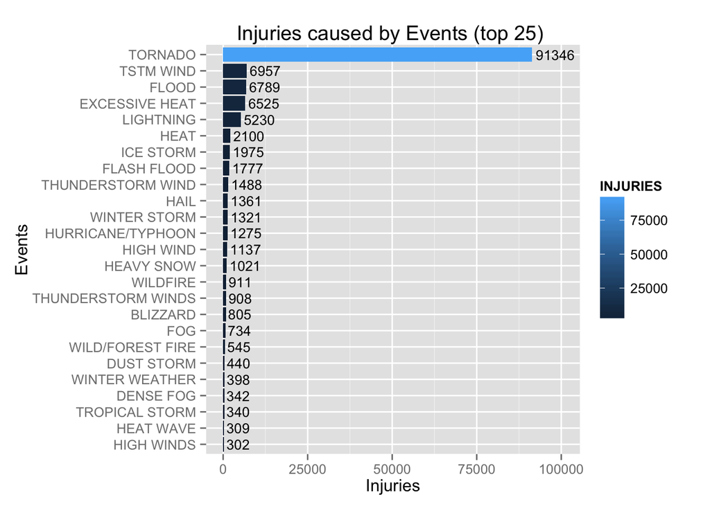

```r
ggplot(data = top25, aes(ymin=0, ymax=INJURIES+INJURIES * 0.1,
                         x=EVTYPE, y=INJURIES, fill = INJURIES)) +
    geom_bar(stat = "identity") +
    xlab("Events") +
    ylab("Injuries") +
    ggtitle("Injuries caused by Events (top 25) ") +
    coord_flip() +
    geom_text(size=3.5, aes(label=INJURIES),
              position = position_dodge(width=0.1), hjust = -0.1)
```

As shown in the plot above, tornado is the most harmful event which causes injuries as well.

##### 3.3 The most harmful events result in property damanges

Read the data and calculat the economic cost using data$PROPDMG and data$PROPDMGEXP:

```r
data$PROPDMGEXP <- toupper(data$PROPDMGEXP)

calcExp <- function(x, exp = "") {
    switch(exp,
           `1` = x, `2` = x * (10^2), `3` = x * (10^3),
           `4` = x * (10^4), `5` = x * (10^5), `6` = x * (10^6),
           `7` = x * (10^7), `8` = x * (10^8),
           H = x * 100, K = x * 1000,
           M = x * 1e+06, B = x * 1e+09,
           `-` = x * -1, `?` = x, `+` = x,
           x)
}

applyCalcExp <- function(vx, vexp) {
    if (length(vx) != length(vexp))
        stop("Not same size")
    result <- rep(0, length(vx))
    for (i in 1:length(vx)) {
        result[i] <- calcExp(vx[i], vexp[i])
    }
    result
}

data$EconomicCosts <- applyCalcExp(as.numeric(data$PROPDMG), data$PROPDMGEXP)
```

Select the top 25 events and reorder the factor level:

```r
cost <- as.data.table(subset(aggregate(EconomicCosts ~ EVTYPE, data = data,
                                           FUN = "sum"), EconomicCosts > 0))
cost <- cost[order(-EconomicCosts), ]
cost$EVTYPE <- reorder(cost$EVTYPE, cost$EconomicCosts)
top25 <- cost[1:25, ]
```

Plot the top 25 events causing most economic cost:

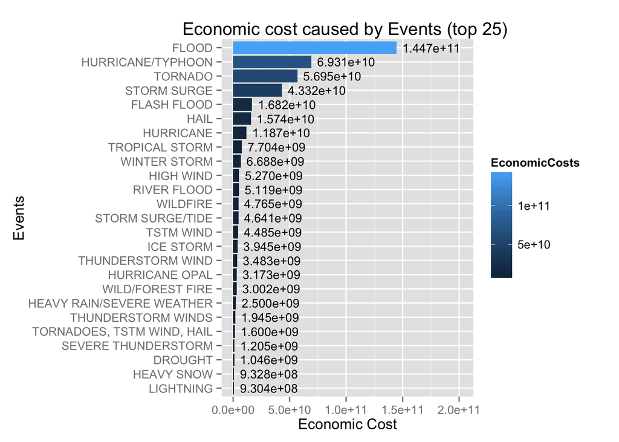

```r
ggplot(data = top25, aes(ymin=0, ymax=EconomicCosts + EconomicCosts * 0.4,
                         x=EVTYPE, y=EconomicCosts, fill = EconomicCosts)) +
    geom_bar(stat = "identity") +
    xlab("Events") +
    ylab("Economic Cost") +
    ggtitle("Economic cost caused by Events (top 25) ") +
    coord_flip() +
    geom_text(size=3.5, aes(label=format(EconomicCosts, scientific=TRUE)),
              position = position_dodge(width=0.1), hjust = -0.1)
```

As shown in the plot above, flood is the most harmful event which results in most economic cost.